# tarea 2

Equipo CAL: Carlos Petricioli, Amanda Balderas, Liliana Millán

15 de noviembre de 2014

# Introducción

Archivo algas 200 observaciones, obtenido del repositorio de Adolfo de Unanue Tiscareño .

Este set de datos corresonde a muestras de agua tomadas de diferenes ríos de Europa por un año para realizar un estudio de calidad de agua, al mismo tiempo se tomaron muestras de algas en estos ríos para determinar las distribuciónes de población de algas en estos ríos.

## Variables

El set contiene 18 atributos en el siguiente orden:

[output not shown]

Los NA están codificados como XXXXXXX.

# Estructura General

```r
ds
```

```
## Source: local data frame [200 x 18]
##
##        V1    V2     V3   V4   V5    V6     V7     V8     V9    V10    V11
## 1  winter small medium 8.00  9.8 60.80  6.238 578.00 105.00 170.00 50.000
## 2  spring small medium 8.35  8.0 57.75  1.288 370.00 428.75 558.75  1.300
## 3  autumn small medium 8.10 11.4 40.02  5.330 346.67 125.67 187.06 15.600
## 4  spring small medium 8.07  4.8 77.36  2.302  98.18  61.18 138.70  1.400
## 5  autumn small medium 8.06  9.0 55.35 10.416 233.70  58.22  97.58 10.500
## 6  winter small   high 8.25 13.1 65.75  9.248 430.00  18.25  56.67 28.400
## 7  summer small   high 8.15 10.3 73.25  1.535 110.00  61.25 111.75  3.200
## 8  autumn small   high 8.05 10.6 59.07  4.990 205.67  44.67  77.43  6.900
## 9  winter small medium 8.70  3.4 21.95  0.886 102.75  36.30  71.00  5.544
## 10 winter small   high 7.93  9.9  8.00  1.390   5.80  27.25  46.60  0.800
## ..    ...   ...    ...  ...  ...   ...    ...    ...    ...    ...    ...
## Variables not shown: V12 (dbl), V13 (dbl), V14 (dbl), V15 (dbl), V16
##   (dbl), V17 (dbl), V18 (dbl)
```

## Tamaño

```r
dim(ds)
```

```
## [1] 200  18
```

## Columnas

```r
names(ds)
```

```
##  [1] "V1"  "V2"  "V3"  "V4"  "V5"  "V6"  "V7"  "V8"  "V9"  "V10" "V11"
## [12] "V12" "V13" "V14" "V15" "V16" "V17" "V18"
```

## Estructura

```r
str(ds)
```

```
## Classes 'tbl_df', 'tbl' and 'data.frame':    200 obs. of  18 variables:
##  $ V1 : Factor w/ 4 levels "autumn","spring",..: 4 2 1 2 1 4 3 1 4 4 ...
##  $ V2 : Factor w/ 3 levels "large","medium",..: 3 3 3 3 3 3 3 3 3 3 ...
##  $ V3 : Factor w/ 3 levels "high","low","medium": 3 3 3 3 3 1 1 1 3 1 ...
##  $ V4 : num  8 8.35 8.1 8.07 8.06 8.25 8.15 8.05 8.7 7.93 ...
##  $ V5 : num  9.8 8 11.4 4.8 9 13.1 10.3 10.6 3.4 9.9 ...
##  $ V6 : num  60.8 57.8 40 77.4 55.4 ...
##  $ V7 : num  6.24 1.29 5.33 2.3 10.42 ...
##  $ V8 : num  578 370 346.7 98.2 233.7 ...
##  $ V9 : num  105 428.8 125.7 61.2 58.2 ...
##  $ V10: num  170 558.8 187.1 138.7 97.6 ...
##  $ V11: num  50 1.3 15.6 1.4 10.5 ...
##  $ V12: num  0 1.4 3.3 3.1 9.2 15.1 2.4 18.2 25.4 17 ...
##  $ V13: num  0 7.6 53.6 41 2.9 14.6 1.2 1.6 5.4 0 ...
##  $ V14: num  0 4.8 1.9 18.9 7.5 1.4 3.2 0 2.5 0 ...
##  $ V15: num  0 1.9 0 0 0 0 3.9 0 0 2.9 ...
##  $ V16: num  34.2 6.7 0 1.4 7.5 22.5 5.8 5.5 0 0 ...
##  $ V17: num  8.3 0 0 0 4.1 12.6 6.8 8.7 0 0 ...
##  $ V18: num  0 2.1 9.7 1.4 1 2.9 0 0 0 1.7 ...
```

```r
#temporada
unique(ds$V1)
```

```
## [1] winter spring autumn summer
## Levels: autumn spring summer winter
```

```r
#tamaño del rio
unique(ds$V2)
```

```
## [1] small  medium large
## Levels: large medium small
```

```r
#velocidad
unique(ds$V3)
```

```
## [1] medium high   low
## Levels: high low medium
```

```r
#4-11 concentraciones quimicas
str(ds[,4:11])
```

```
## Classes 'tbl_df', 'tbl' and 'data.frame':    200 obs. of  8 variables:
##  $ V4 : num  8 8.35 8.1 8.07 8.06 8.25 8.15 8.05 8.7 7.93 ...
##  $ V5 : num  9.8 8 11.4 4.8 9 13.1 10.3 10.6 3.4 9.9 ...
##  $ V6 : num  60.8 57.8 40 77.4 55.4 ...
##  $ V7 : num  6.24 1.29 5.33 2.3 10.42 ...
##  $ V8 : num  578 370 346.7 98.2 233.7 ...
##  $ V9 : num  105 428.8 125.7 61.2 58.2 ...
##  $ V10: num  170 558.8 187.1 138.7 97.6 ...
##  $ V11: num  50 1.3 15.6 1.4 10.5 ...
```

```r
#12-19 distribuciones de diferentes algas
str(ds[,12:18])
```

```
## Classes 'tbl_df', 'tbl' and 'data.frame':    200 obs. of  7 variables:
##  $ V12: num  0 1.4 3.3 3.1 9.2 15.1 2.4 18.2 25.4 17 ...
##  $ V13: num  0 7.6 53.6 41 2.9 14.6 1.2 1.6 5.4 0 ...
##  $ V14: num  0 4.8 1.9 18.9 7.5 1.4 3.2 0 2.5 0 ...
##  $ V15: num  0 1.9 0 0 0 0 3.9 0 0 2.9 ...
##  $ V16: num  34.2 6.7 0 1.4 7.5 22.5 5.8 5.5 0 0 ...
##  $ V17: num  8.3 0 0 0 4.1 12.6 6.8 8.7 0 0 ...
##  $ V18: num  0 2.1 9.7 1.4 1 2.9 0 0 0 1.7 ...
```

No hay discrepancia entre las clases de variables y su significado.

## Observaciones

```r
head(ds)
```

```
## Source: local data frame [6 x 18]
##
##       V1    V2     V3   V4   V5    V6     V7     V8     V9    V10  V11
## 1 winter small medium 8.00  9.8 60.80  6.238 578.00 105.00 170.00 50.0
## 2 spring small medium 8.35  8.0 57.75  1.288 370.00 428.75 558.75  1.3
## 3 autumn small medium 8.10 11.4 40.02  5.330 346.67 125.67 187.06 15.6
## 4 spring small medium 8.07  4.8 77.36  2.302  98.18  61.18 138.70  1.4
## 5 autumn small medium 8.06  9.0 55.35 10.416 233.70  58.22  97.58 10.5
## 6 winter small   high 8.25 13.1 65.75  9.248 430.00  18.25  56.67 28.4
## Variables not shown: V12 (dbl), V13 (dbl), V14 (dbl), V15 (dbl), V16
##   (dbl), V17 (dbl), V18 (dbl)
```

```r
tail(ds)
```

```
## Source: local data frame [6 x 18]
##
##         V1    V2     V3  V4   V5     V6    V7     V8    V9    V10    V11
## 195 summer large medium 8.5  7.9  12.44 2.586  96.67 19.11  61.44  6.167
## 196 autumn large medium 8.4  8.4  17.38 3.833  83.75 53.62  79.75  2.338
## 197 spring large medium 8.3 10.6  14.32 3.200 125.33 35.33  75.90  4.667
## 198 autumn large medium 8.2  7.0 139.99 2.978  60.11 78.33 140.22 31.738
## 199 winter large medium 8.0  7.6     NA    NA     NA    NA     NA     NA
## 200 summer large medium 8.5  6.7  82.85 2.800  27.07 64.00 140.52 18.300
## Variables not shown: V12 (dbl), V13 (dbl), V14 (dbl), V15 (dbl), V16
##   (dbl), V17 (dbl), V18 (dbl)
```

```r
ds[sample(1:dim(ds)[1],6),]
```

```
## Source: local data frame [6 x 18]
##
##         V1     V2     V3  V4   V5     V6     V7      V8     V9    V10
## 178 spring  large   high 8.1 10.7  3.500  1.013    12.5  12.75  11.00
## 165 winter  large   high 7.3  9.9 16.000  4.820   101.7  14.67  85.00
## 123 summer medium medium 8.1  9.0 48.429  6.640   128.6 181.00 222.29
## 108 autumn medium   high 8.3 11.1 41.500  4.665   931.8  39.00 124.20
## 153 autumn medium   high 7.3 11.8 44.205 45.650 24064.0  44.00  34.00
## 116 winter medium   high 9.7 10.8  0.222  0.406    10.0  22.44  10.11
## Variables not shown: V11 (dbl), V12 (dbl), V13 (dbl), V14 (dbl), V15
##   (dbl), V16 (dbl), V17 (dbl), V18 (dbl)
```

# Sumario Estadístico

```r
summary(ds)
```

```
##       V1          V2          V3           V4             V5
##  autumn:40   large :45   high  :84   Min.   :5.60   Min.   : 1.50
##  spring:53   medium:84   low   :33   1st Qu.:7.70   1st Qu.: 7.72
##  summer:45   small :71   medium:83   Median :8.06   Median : 9.80
##  winter:62                           Mean   :8.01   Mean   : 9.12
##                                      3rd Qu.:8.40   3rd Qu.:10.80
##                                      Max.   :9.70   Max.   :13.40
##                                      NA's   :1      NA's   :2
##        V6              V7              V8              V9
##  Min.   :  0.2   Min.   : 0.05   Min.   :    5   Min.   :  1.0
##  1st Qu.: 11.0   1st Qu.: 1.30   1st Qu.:   38   1st Qu.: 15.7
##  Median : 32.7   Median : 2.67   Median :  103   Median : 40.1
##  Mean   : 43.6   Mean   : 3.28   Mean   :  501   Mean   : 73.6
##  3rd Qu.: 57.8   3rd Qu.: 4.45   3rd Qu.:  227   3rd Qu.: 99.3
##  Max.   :391.5   Max.   :45.65   Max.   :24064   Max.   :564.6
##  NA's   :10      NA's   :2       NA's   :2       NA's   :2
##       V10             V11              V12             V13
##  Min.   :  1.0   Min.   :  0.20   Min.   : 0.00   Min.   : 0.00
##  1st Qu.: 41.4   1st Qu.:  2.00   1st Qu.: 1.50   1st Qu.: 0.00
##  Median :103.3   Median :  5.47   Median : 6.95   Median : 3.00
##  Mean   :137.9   Mean   : 13.97   Mean   :16.92   Mean   : 7.46
##  3rd Qu.:213.8   3rd Qu.: 18.31   3rd Qu.:24.80   3rd Qu.:11.38
##  Max.   :771.6   Max.   :110.46   Max.   :89.80   Max.   :72.60
##  NA's   :2       NA's   :12
##       V14             V15             V16             V17
##  Min.   : 0.00   Min.   : 0.00   Min.   : 0.00   Min.   : 0.00
##  1st Qu.: 0.00   1st Qu.: 0.00   1st Qu.: 0.00   1st Qu.: 0.00
##  Median : 1.55   Median : 0.00   Median : 1.90   Median : 0.00
##  Mean   : 4.31   Mean   : 1.99   Mean   : 5.06   Mean   : 5.96
##  3rd Qu.: 4.92   3rd Qu.: 2.40   3rd Qu.: 7.50   3rd Qu.: 6.92
##  Max.   :42.80   Max.   :44.60   Max.   :44.40   Max.   :77.60
##
##       V18
##  Min.   : 0.0
##  1st Qu.: 0.0
##  Median : 1.0
##  Mean   : 2.5
##  3rd Qu.: 2.4
##  Max.   :31.6
##
```

# Limpieza de metadatos

Cambiando nombre a las columnas

```
##  [1] "temporada"  "tamaño_rio" "velocidad"  "cq_1"       "cq_2"
##  [6] "cq_3"       "cq_4"       "cq_5"       "cq_6"       "cq_7"
## [11] "cq_8"       "da_1"       "da_2"       "da_3"       "da_4"
## [16] "da_5"       "da_6"       "da_7"
```

# Ajuste de formatos

Las clases de las variables son

```r
sapply(ds, class)
```

```
##  temporada tamaño_rio  velocidad       cq_1       cq_2       cq_3
##   "factor"   "factor"   "factor"  "numeric"  "numeric"  "numeric"
##       cq_4       cq_5       cq_6       cq_7       cq_8       da_1
##  "numeric"  "numeric"  "numeric"  "numeric"  "numeric"  "numeric"
##       da_2       da_3       da_4       da_5       da_6       da_7
##  "numeric"  "numeric"  "numeric"  "numeric"  "numeric"  "numeric"
```

En este set de datos no hay fechas.

# Transformación de variables

No se realizó ninguna transformación.

En el set de datos de algas no hay una variable risk ni costo asociada a la variable target.

Se ocupó como id el rowname.

# Recodificación

No se requirió recodificar las variables categóricas ya que tienen a lo más 4 niveles y no hay variables de fechas.

# Variables a ignorar

Ignoraremos las últimas 7 columnas que son las variables que queremos inferir.

### IDs y variables de salida

### Constantes y valores únicos por observación

En el set de datos de algas no se encontraron muchos niveles, el de mayor nivel tiene 4 niveles diferentes (temporada), tampoco se encontraron variables que sean constantes.

```
## character(0)
```

### Faltantes

```r
# Las que sean puros NAs
ids.nas.count <- sapply(ds[vars], function(x) sum(is.na(x)))
ids.nas <- names(which(ids.nas.count == nrow(ds)))

vars.a.ignorar <- union(ids.nas, vars.a.ignorar)

# Las que tengan muchos NAs (un 70% o más)
ids.many.nas <- names(which(ids.nas.count >= 0.7*nrow(ds)))

vars.a.ignorar <- union(ids.many.nas, vars.a.ignorar)
```

### Variable de salida (`target`)

No hubo NA’s en las columnas target.

```
## [1] 200  18
```

```
## [1] 200  18
```

Mostramos la distribución (esto nos indicará si el problema no está balanceado)

[output not shown]

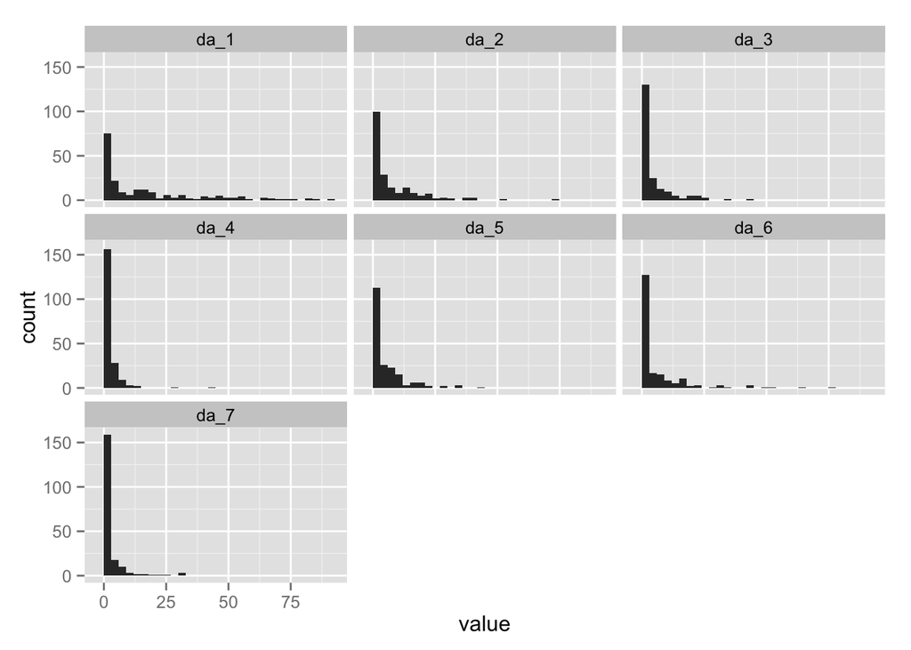

También se muestran las variables target en boxplot

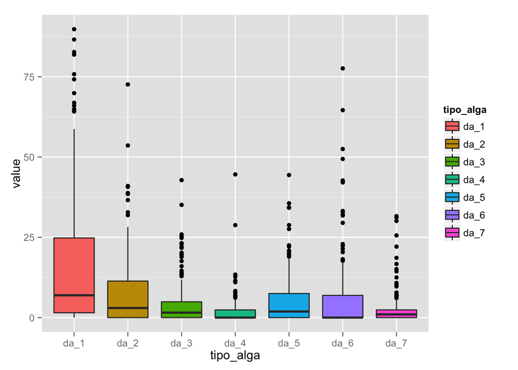

# Variables correlacionadas

```r
vars.cor <- cor(ds[which(sapply(ds, is.numeric))], use="complete.obs")
vars.cor[upper.tri(vars.cor, diag=TRUE)] <- NA

vars.cor <- vars.cor                                  %>%
            abs()                                     %>%
            data.frame()                              %>%
            mutate(var1=row.names(vars.cor))          %>%
            gather(var2, cor, -var1)                  %>%
            na.omit()


vars.cor <- vars.cor[order(-abs(vars.cor$cor)), ]

(muy.cor <- filter(vars.cor, cor > 0.95)) # Mostramos las que tengan más del 95% de correlación

# Habría que decidir si se remueven y cuales se remueven (var1 o var2)
vars.a.ignorar <- union(vars.a.ignorar, muy.cor$var2)
```

No hubo columnas que tuvieran mas del 95% de correlacion entre ellas

# Valores faltantes

La estrategia a seguir será la de eleminar las observaciones cuyos valores tengan más del 25% de NAs. Aquellas que tienen menos del 25% los valores de NAs se modificarán a través de una regresión lineal, media/mediana/moda dependiendo de la distribución de cada variable.

De la correlación entre faltantes: Los faltantes en la cq_6 y cq_5 están correlacionados positivamente al 100% al igual que los faltantes en cq_6 y cq_4, esto significa que cuando falta un valor en cq_6 tambien falta en cq_4 y cq_5. La correlación entre cq_8 y cq_3 también es muy alta positivamente más del 75%.

```
##       V1    V2     V3   V4   V5    V6     V7     V8     V9    V10  V11
## 1 winter small medium 8.00  9.8 60.80  6.238 578.00 105.00 170.00 50.0
## 2 spring small medium 8.35  8.0 57.75  1.288 370.00 428.75 558.75  1.3
## 3 autumn small medium 8.10 11.4 40.02  5.330 346.67 125.67 187.06 15.6
## 4 spring small medium 8.07  4.8 77.36  2.302  98.18  61.18 138.70  1.4
## 5 autumn small medium 8.06  9.0 55.35 10.416 233.70  58.22  97.58 10.5
## 6 winter small   high 8.25 13.1 65.75  9.248 430.00  18.25  56.67 28.4
##    V12  V13  V14 V15  V16  V17 V18
## 1  0.0  0.0  0.0 0.0 34.2  8.3 0.0
## 2  1.4  7.6  4.8 1.9  6.7  0.0 2.1
## 3  3.3 53.6  1.9 0.0  0.0  0.0 9.7
## 4  3.1 41.0 18.9 0.0  1.4  0.0 1.4
## 5  9.2  2.9  7.5 0.0  7.5  4.1 1.0
## 6 15.1 14.6  1.4 0.0 22.5 12.6 2.9
```

```
##   temporada tamaño_rio velocidad cq_1 cq_2 cq_3 cq_4 cq_5 cq_6 cq_7 cq_8
## 1         0          0         0    0    0    0    0    0    0    0    0
## 2         0          0         0    0    0    0    0    0    0    0    0
## 3         0          0         0    0    0    0    0    0    0    0    0
## 4         0          0         0    0    0    0    0    0    0    0    0
## 5         0          0         0    0    0    0    0    0    0    0    0
## 6         0          0         0    0    0    0    0    0    0    0    0
##   da_1 da_2 da_3 da_4 da_5 da_6 da_7
## 1    0    0    0    0    0    0    0
## 2    0    0    0    0    0    0    0
## 3    0    0    0    0    0    0    0
## 4    0    0    0    0    0    0    0
## 5    0    0    0    0    0    0    0
## 6    0    0    0    0    0    0    0
```

```
##           cq_1      cq_2     cq_3      cq_4      cq_5      cq_6      cq_7
## cq_1  1.000000 -0.007125 -0.01626 -0.007125 -0.007125 -0.007125 -0.007125
## cq_2 -0.007125  1.000000  0.20751  0.494949  0.494949  0.494949 -0.010101
## cq_3 -0.016263  0.207514  1.00000  0.438086  0.438086  0.438086  0.207514
## cq_4 -0.007125  0.494949  0.43809  1.000000  1.000000  1.000000  0.494949
## cq_5 -0.007125  0.494949  0.43809  1.000000  1.000000  1.000000  0.494949
## cq_6 -0.007125  0.494949  0.43809  1.000000  1.000000  1.000000  0.494949
## cq_7 -0.007125 -0.010101  0.20751  0.494949  0.494949  0.494949  1.000000
## cq_8 -0.017910  0.186207  0.81145  0.397805  0.397805  0.397805  0.186207
##          cq_8
## cq_1 -0.01791
## cq_2  0.18621
## cq_3  0.81145
## cq_4  0.39781
## cq_5  0.39781
## cq_6  0.39781
## cq_7  0.18621
## cq_8  1.00000
```

[figure not shown]

Variables con más faltantes: en cq_8 el 6% de sus datos son faltantes, cq_3 el 5% de sus datos son faltantes.

```r
apply(ds, 2, function(x) mean(is.na(x))*100)
```

```
##  temporada tamaño_rio  velocidad       cq_1       cq_2       cq_3
##        0.0        0.0        0.0        0.5        1.0        5.0
##       cq_4       cq_5       cq_6       cq_7       cq_8       da_1
##        1.0        1.0        1.0        1.0        6.0        0.0
##       da_2       da_3       da_4       da_5       da_6       da_7
##        0.0        0.0        0.0        0.0        0.0        0.0
```

Observaciones con más faltantes:

```r
apply(ds, 1, function(x) sum(is.na(x)))
```

```
##   1   2   3   4   5   6   7   8   9  10  11  12  13  14  15  16  17  18
##   0   0   0   0   0   0   0   0   0   0   0   0   0   0   0   0   0   0
##  19  20  21  22  23  24  25  26  27  28  29  30  31  32  33  34  35  36
##   0   0   0   0   0   0   0   0   0   1   0   0   0   0   0   0   0   0
##  37  38  39  40  41  42  43  44  45  46  47  48  49  50  51  52  53  54
##   0   1   0   0   0   0   0   0   0   0   0   1   0   0   0   0   0   0
##  55  56  57  58  59  60  61  62  63  64  65  66  67  68  69  70  71  72
##   2   2   2   2   2   2   2   6   1   0   0   0   0   0   0   0   0   0
##  73  74  75  76  77  78  79  80  81  82  83  84  85  86  87  88  89  90
##   0   0   0   0   0   0   0   0   0   0   0   0   0   0   0   0   0   0
##  91  92  93  94  95  96  97  98  99 100 101 102 103 104 105 106 107 108
##   0   0   0   0   0   0   0   0   0   0   0   0   0   0   0   0   0   0
## 109 110 111 112 113 114 115 116 117 118 119 120 121 122 123 124 125 126
##   0   0   0   0   0   0   0   1   0   0   0   0   0   0   0   0   0   0
## 127 128 129 130 131 132 133 134 135 136 137 138 139 140 141 142 143 144
##   0   0   0   0   0   0   0   0   0   0   0   0   0   0   0   0   0   0
## 145 146 147 148 149 150 151 152 153 154 155 156 157 158 159 160 161 162
##   0   0   0   0   0   0   0   0   0   0   0   0   0   0   0   0   1   0
## 163 164 165 166 167 168 169 170 171 172 173 174 175 176 177 178 179 180
##   0   0   0   0   0   0   0   0   0   0   0   0   0   0   0   0   0   0
## 181 182 183 184 185 186 187 188 189 190 191 192 193 194 195 196 197 198
##   0   0   0   1   0   0   0   0   0   0   0   0   0   0   0   0   0   0
## 199 200
##   6   0
```

```r
ds[apply(ds, 1, function(x) sum(is.na(x))) > 2,]
```

```
## Source: local data frame [2 x 18]
##
##     temporada tamaño_rio velocidad cq_1 cq_2 cq_3 cq_4 cq_5 cq_6 cq_7 cq_8
## 62     summer      small    medium  6.4   NA   NA   NA   NA   NA   14   NA
## 199    winter      large    medium  8.0  7.6   NA   NA   NA   NA   NA   NA
## Variables not shown: da_1 (dbl), da_2 (dbl), da_3 (dbl), da_4 (dbl), da_5
##   (dbl), da_6 (dbl), da_7 (dbl)
```

Eliminando las observaciones que tengan más del 25% con NAs.

```
## [1] 16
```

```
## [1] 200  18
```

```
## [1] 198  18
```

En el caso de algas no hay valores NAs en las variables categóricas.

Verificando la distribución de datos para las numéricas para obtener la mejor estrategia para imputar los valores faltantes.

```
##  temporada tamaño_rio  velocidad       cq_1       cq_2       cq_3
##   "factor"   "factor"   "factor"  "numeric"  "numeric"  "numeric"
##       cq_4       cq_5       cq_6       cq_7       cq_8       da_1
##  "numeric"  "numeric"  "numeric"  "numeric"  "numeric"  "numeric"
##       da_2       da_3       da_4       da_5       da_6       da_7
##  "numeric"  "numeric"  "numeric"  "numeric"  "numeric"  "numeric"
```

```
## [1] 1584    2
```

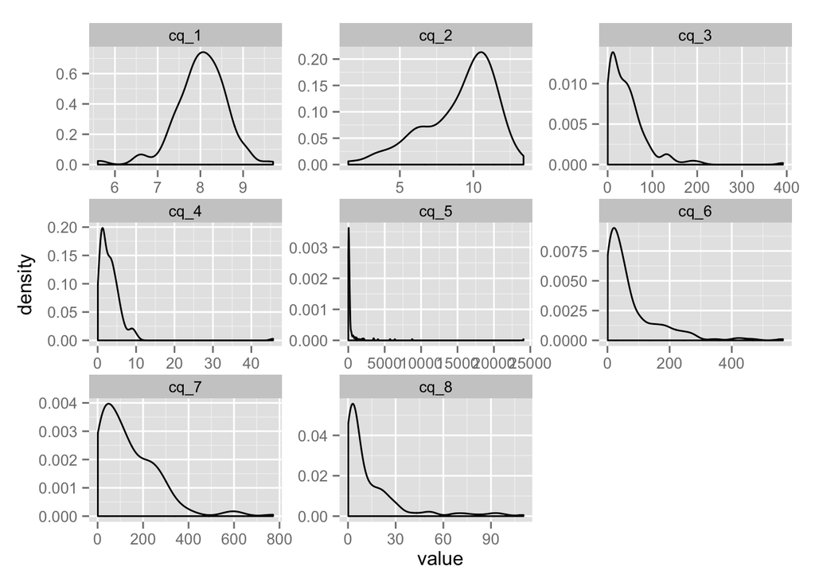

También mostramos las numéricas en boxplots, en cq_5 se identifica que hay un outlier muy ‘grande’

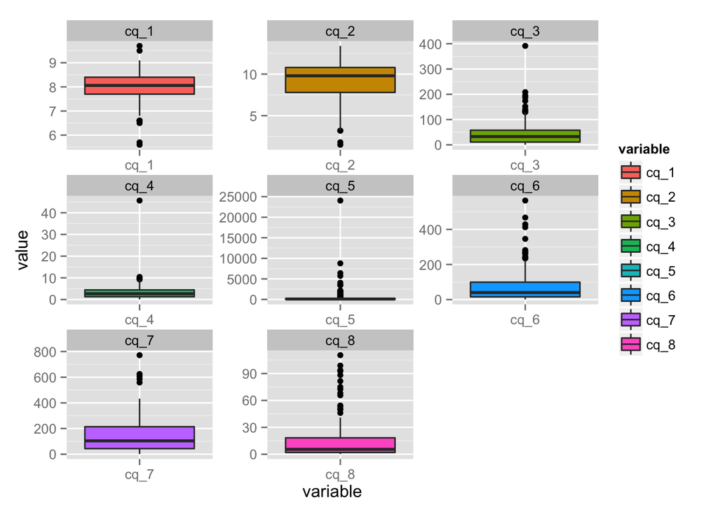

De acuerdo a las distribuciones tomaremos la **media** como valor de reemplazo en los valores faltantes.

Número de NAs antes de cambiarlos por la media.

```
## $cq_1
## [1] 1
##
## $cq_2
## [1] 1
##
## $cq_3
## [1] 8
##
## $cq_4
## [1] 0
##
## $cq_5
## [1] 0
##
## $cq_6
## [1] 0
##
## $cq_7
## [1] 1
##
## $cq_8
## [1] 10
```

Verificamos que ya no hay NAs.

```
## $cq_1
## [1] 0
##
## $cq_2
## [1] 0
##
## $cq_3
## [1] 0
##
## $cq_4
## [1] 0
##
## $cq_5
## [1] 0
##
## $cq_6
## [1] 0
##
## $cq_7
## [1] 0
##
## $cq_8
## [1] 0
```

# Normalizar niveles

Removemos espacios, puntuaciones, camelCase, etc. en los niveles de los factores supervivientes.

De acuerdo al summary de las variables categóricas no hay acentos, puntuaciones o nombres en formato camelCase

```r
summary(ds[,1:3])
```

```
##   temporada   tamaño_rio  velocidad
##  autumn:40   large :44   high  :84
##  spring:53   medium:84   low   :33
##  summer:44   small :70   medium:81
##  winter:61
```

# Identificación de Variables

```
##  [1] "temporada"  "tamaño_rio" "velocidad"  "cq_1"       "cq_2"
##  [6] "cq_3"       "cq_4"       "cq_5"       "cq_6"       "cq_7"
## [11] "cq_8"
```

```
## [1] "cq_1" "cq_2" "cq_3" "cq_4" "cq_5" "cq_6" "cq_7" "cq_8"
```

```
## [1] "temporada"  "tamaño_rio" "velocidad"
```

Guardamos todo en

```
## [1] "algas_141116.RData"
```

### Apéndice: Ambiente